# Basic summmary and preliminary results for the FastGPS Tag accuracy analysis

Reny Tyson Moore, rtysonmoore@mote.org

May 13, 2020

## FastGPS Analysis - Field Tests

**Updated May 6, 2019:**  
- Edmund Bryant recently updated the location processing system, LocSolve, used to derive the locations from Fastloc records and re-ran the tag data to compare with the older version’s output. Below you will find the results from both location processing runs (old and new LocSolve). With the new processing, all records had residuals less than 35 and 29 records used 5 or more satellites to acquire locations. This resulted in 29 ‘good’ quality locations using the new LocSolve, versus 15 from the older LocSolve version.

**Table 1. Summary statistics of distances estimated between the dolphin’s *true* location and the tag’s esimated location for all FastGPS snaps, as well as those deemed to be ‘good’ quality. Good quality snaps are considered to be those that were acquired using at least 5 satellites and that had residuals less than 35**

| Data | N | mean.distance | median.distance | sd.distance | min.distance | max.distance |
| --- | --- | --- | --- | --- | --- | --- |
| All - Old LocSolve | 54 | 269.914 | 49.178 | 564.152 | 2.10394 | 2926.52 |
| All - New LocSolve | 54 | 49.880 | 30.774 | 60.723 | 0.47081 | 264.83 |
| Good - Old LocSolve | 15 | 70.701 | 38.659 | 84.724 | 2.10394 | 273.14 |
| Good - New LocSolve | 29 | 44.272 | 24.628 | 62.912 | 0.96406 | 264.83 |

**Table 2. Summary statistics for good quality FastGPS location data by PTT ID**

| LocSolve | PTT | N | mean.distance | median.distance | sd.distance | min.distance | max.distance |
| --- | --- | --- | --- | --- | --- | --- | --- |
| Old | 179062 | 4 | 89.003 | 32.347 | 123.149 | 18.18050 | 273.14 |
| New | 179062 | 5 | 70.630 | 26.871 | 109.060 | 6.90712 | 264.83 |
| Old | 179063 | 2 | 61.718 | 61.718 | 70.553 | 11.82915 | 111.61 |
| New | 179063 | 8 | 37.227 | 26.134 | 37.320 | 4.06090 | 118.24 |
| Old | 179064 | 9 | 64.563 | 38.659 | 77.603 | 2.10394 | 253.56 |
| New | 179064 | 16 | 39.558 | 23.062 | 57.312 | 0.96406 | 238.46 |

Tables 1 and 2 demonstrate that the new LocSolve processing system appeared to improve the accuracy of the FastGPS locations in reference to the dolphins true locations.

The difference in the times reported by the FastGPS tag and those used from our focal follow observations and boat tracks to estimate dolphin locations affected the estimated distances between the dolphin and tag locations (Figure 1).

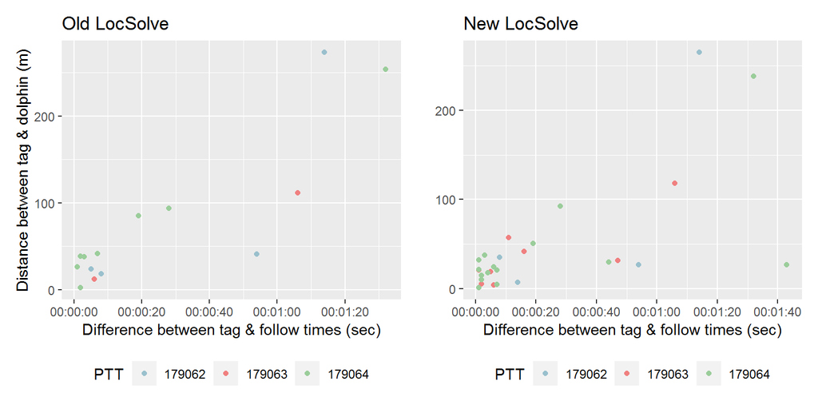

**Figure 1. The relationship between the lag in time between the data transmitted by the tag (old and new LocSolve location processing) and that recorded during our focal follow observations to the distances estimated between the tag and true dolphin location. Note: only good quality FastGPS locations are included.**

Figure 1 shows that for data from both LocSolve versions appear to be most accurate when we consider tag data that was received less than 10 seconds from an observed dolphin surfacing (Table 3). As the time between the dolphin surfacing and location transmitted increases, so does the distance between the estimated distance between the dolphin and the tag location. This is likely related to the dolphins movements between surfacings and the likelihood that the surfacing observed is the surfacing that was used to generate a location on the tag.

**Table 3: Summary statistics for good quality data that has a temporal difference between the reported tag time and the focal follow observation of less than 10 seconds**

| LocSolve | N | mean.distance | median.distance | sd.distance | min.distance | max.distance |
| --- | --- | --- | --- | --- | --- | --- |
| Old | 9 | 22.450 | 23.521 | 15.142 | 2.10394 | 41.722 |
| New | 17 | 17.543 | 19.173 | 10.902 | 0.96406 | 37.387 |

There were many ‘poor’ quality locations that actually seem to be quite accurate, particularly with the new LocSolve (Figures 2 and 3).Does our definition of ‘good’ quality hold with this new LocSolve or should we/can we relax it?

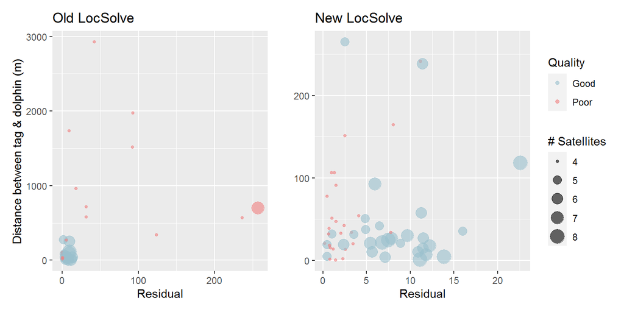

**Figure 2. The relationship between the distances estimated between the tags and dolphins and the resdual of the tag location. The number of satellites is referencd by point size. Our definition of good and poor quality locations is referenced by point color.**

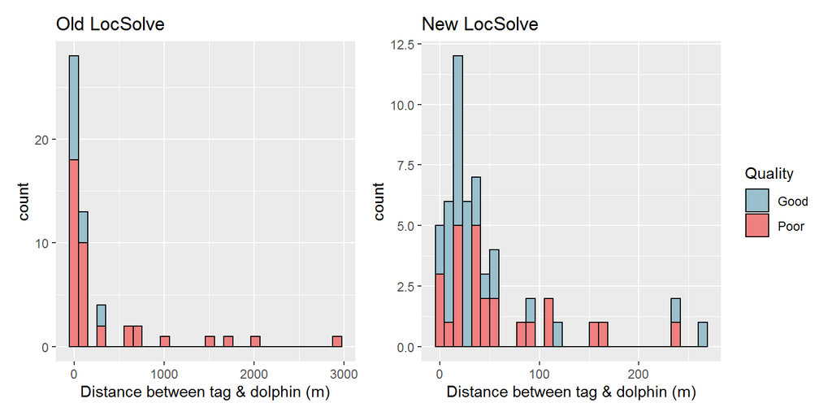

**Figure 3. Histogram of distances estimated between the tags and dolphins with reference to good and poor quality locations.**

The 8 poor tag location records that were highly unlikely or implausible (*e.g.*, points on land or far from where dolphins were known to be) before were ‘fixed’ with the new LocSolve processing, with 6 of the 8 points now being ‘good’ quality and reasonable estimates.

**Table 4. Summary statistics for good quality data from the bench test using old and new LocSolve processing.**

| LocSolve | N | mean.distance | median.distance | sd.distance | min.distance | max.distance |
| --- | --- | --- | --- | --- | --- | --- |
| Old | 30 | 25.839 | 22.685 | 33.942 | 1.58671 | 192.59 |
| New | 30 | 26.613 | 24.602 | 24.668 | 0.67792 | 129.73 |

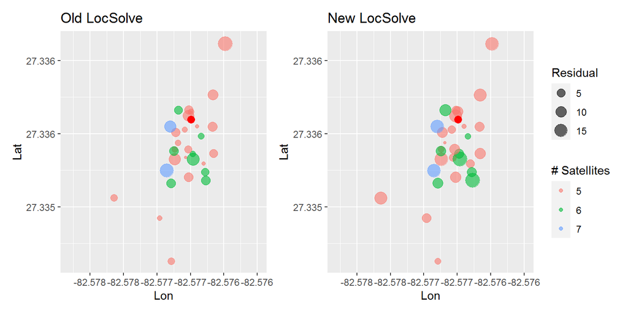

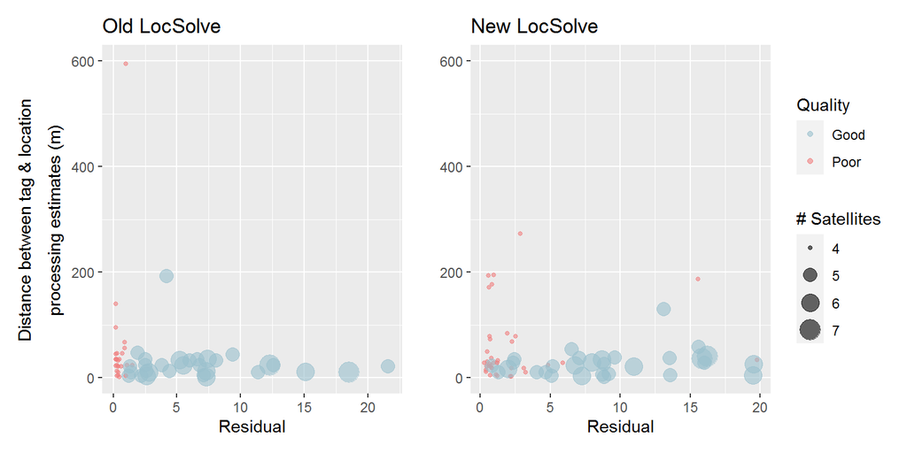

**Figure 5. The relationship between the distances estimated between the tag’s true location and the resdual of the tag location for each method. The number of satellites is referencd by point size. Good and poor quality locations are referenced by point color.**

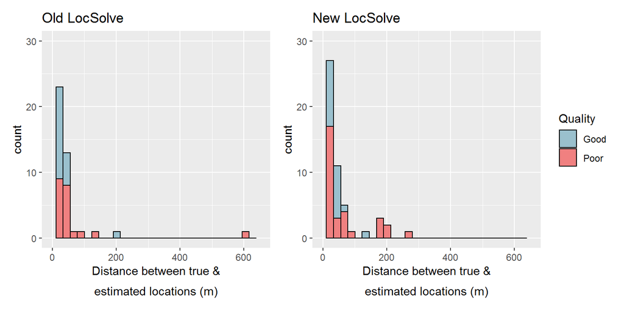

## Argos - Field Tests

Argos locations were analysed the same was as the FastGPS locations. I did not do any extra processing of these locations yet - for now I just used the locations provided in the outputs from the data portal. We had 25 Argos ‘snaps’ (*i.e.*, matching records) within 2 minutes of the focal follow observations (179062 = 8, 179063 = 13, 179064 = 4). Five distances of dolphin locations were estimated with a range finder, all others were estimated by eye.

**Table 5. Summary statistics of distances for all Argos snaps**

| Quality | N | mean.distance | median.distance | sd.distance | min.distance | max.distance |
| --- | --- | --- | --- | --- | --- | --- |
| 3 | 6 | 601.07 | 578.12 | 229.96 | 306.80 | 924.72 |
| 2 | 5 | 638.77 | 291.46 | 980.30 | 49.67 | 2383.26 |
| 1 | 4 | 642.01 | 583.93 | 558.51 | 49.29 | 1350.90 |
| 0 | 4 | 1322.18 | 1043.40 | 979.67 | 495.21 | 2706.72 |
| A | 2 | 2224.51 | 2224.51 | 2842.94 | 214.26 | 4234.77 |
| B | 4 | 2910.51 | 2260.92 | 2581.14 | 567.59 | 6552.63 |

**Table 6. Summary statistics of distances for all Argos snaps broken down by PTT ID for LCs: 3, 2, and 1**

| Quality | N | mean.distance | median.distance | sd.distance | min.distance | max.distance |
| --- | --- | --- | --- | --- | --- | --- |
| 179062 |  |  |  |  |  |  |
| 3 | 1 | 797.85 | 797.85 | NaN | 797.85 | 797.85 |
| 2 | 3 | 988.92 | 292.04 | 1207.53 | 291.46 | 2383.26 |
| 1 | 1 | 389.99 | 389.99 | NaN | 389.99 | 389.99 |
| 179063 |  |  |  |  |  |  |
| 3 | 3 | 441.91 | 420.80 | 146.80 | 306.80 | 598.12 |
| 2 | 1 | 49.67 | 49.67 | NaN | 49.67 | 49.67 |
| 1 | 3 | 726.02 | 777.86 | 652.35 | 49.29 | 1350.90 |
| 179064 |  |  |  |  |  |  |
| 3 | 2 | 741.42 | 741.42 | 259.22 | 558.13 | 924.72 |
| 2 | 1 | 177.44 | 177.44 | NaN | 177.44 | 177.44 |

The distances estimated between the dolphins ‘true’ location and the location generated by Argos are much larger than the FastGPS locations for all location classes (as we would expect).

The difference in the times reported by Argos and those used from our focal follow observations and boat tracks to estimate dolphin locations did not affect the estimated distances between the dolphin and tag locations as significantly as for the FastGPS estimates (Figure 7). This is probably related to how the Argos location is created during a pass and how the timestamp reported by Argos for each location is dependent on the length of the pass (which can be > 10 min) (Matt - please correct me if I am wrong).

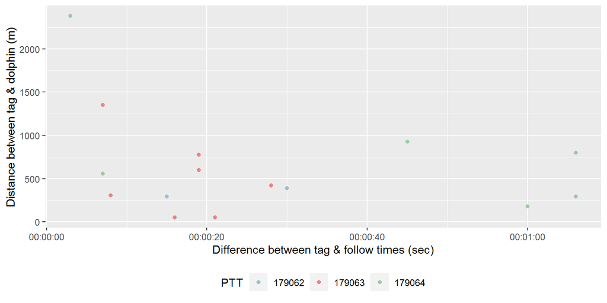

**Figure 7. The relationship between the lag in time between the data transmitted by the tag and that recorded during our focal follow observations to the distances estimated between the tag and true dolphin location. Note: only Argos LCs: 3, 2, and 1 are included.**

If desired, I can run these data through crawl or foieGras to interpolate each tag’s movement path and predict locations that are close to our focal follow observation times.

[output not shown]

## Things to decide for the manuscript:

- Do we include results from both location processing techniques (old and new), or just one?
- Do we include comparisons with Argos locations as well, or just focus on the Fastloc locations?
- Do we include the bench test results?
- Decide Target Journal: Methods in Ecology and Evolution (possibly good followup to Dujon paper depending on what we decide to include), Movement Ecology, Animal Biotelemetry, or other